# Prediction Assignment - DA3

## Data Selection & Engineering

The dataset came with a large number of columns due to the source of it being web-scrapping. Hence, even before thinking about the business specific columns, we dropped the columns such as, host’s profile picture url, the scrapping id, listing url etc. In total, we dropped 24 columns in the first stage of the data cleaning.

Then certain variables were formatted and cleaned. Price column had the dollar sign in the observations that we had to remove for two reasons; 1- to make the observations viable for our analysis by making it numeric, 2- the dollar signed was indicative of it being price and was not currency specific as the currency was euros in the case of our dataset. Then some of the variables were formatted into binary to give 1 or 0 value, for example, “host_is_superhost”,“host_has_profile_pic”.

We had to conduct intensive data cleaning and preparation prior to running the predictive models. A major part of the preparation process was to extract amenities provided at each apartment and pool them into relevant categories. Some of the amenities had to be dropped considering the relevancy with our built properties and the size of the dataset. Amenities such as lake access, private pool, hot tub and a few others which were not relevant in our case; our apartments, for example, currently have a shared pool and there are no lakes near our properties, only the ocean that is covered by another amenity. Moreover, variables were divided into numeric, categorical, and dummy types for easier analysis.

To talk more about how amenities for the properties were provided in the dataset and how these were extracted into individual columns, following is a quick snippet of some of that code. It was one of the challenging tasks of this project. After doing large amount of research, we found some codes from last year’s student Github, Viki, who had successfully completed this task. The code first remove the brackets, spaces, and commas from the observations. Then it divides all the individual names in each observations into separate columns in a new data frame. We then defined our list of amenities that we would like to see, based on which a for loop was run that looked at the columns in this new dataframe. If our defined keyword/keywords were found in multiple columns for the same observation, a value of 1 was assigned where the particular keyword was found for the observation across all the newly created columns, otherwise 0. This was done for all our specified keywords to obtain similar results. We then looked at all these newly created columns and only kept the ones which had observations of value 1 at least 1% and at most 99% to bring diversity in the column values.

```r
# Defining levels and dummies
levs <- levels(factor(unlist(data$amenities)))
data<-cbind(data,as.data.frame(do.call(rbind, lapply(lapply(data$amenities, factor, levs), table))))

# Looking at the column names we have
levs <- sort(names(ams))

# Merging all the columns with the same column name
ams <- as.data.frame(do.call(cbind, by(t(ams), INDICES= names(ams),FUN=colSums)))

# list of key words to merge together
cat <- c( "kitchen", "stove", "oven", "frige","o_machine|ee_machine|coffee", "gril",
         "free.*on_premises", "free.*street", "paid.*on_premis|valet", "paid.*off_premises|self-parking|parking",
         "wifi|internet", "netflix|tv.*netflix", "cable", "tv", "sound_system",
         "toiletries", "shampoo|conditioner", "body_soap|gel", "hair_dryer", "washer", "dryer", "iron",
         "heating", "air_cond|fan", "balcony|terrace", "garden",
         "onsite_bar|restaurant", "breakfast",  "work|office", "spa",  "fitness|gym",
         "children|baby|crib|high|corner|chang", "smoking", "housekeeping", "fireplace", "clothing_storage"
         )

# function to merge columns with the same key word in them
for (i in cat) {
  tdata <- ams %>% select(matches(i))
  ams$new_col <- ifelse(rowSums(tdata)>0, 1, 0)
  names(ams)[names(ams) == "new_col"] <- paste0("have_", i)
  ams <- ams %>% select(-colnames(tdata))}

# keep only columns where the percentage of 1s is at least 1% and at most 99%
selected <- sapply(names(ams), function(x){
  ratio <- sum(ams[[x]])/nrow(ams)*100
  if (between(ratio, 1, 99)) {
    return(TRUE)
  } else { return(FALSE) }
})
```

The models built for the purpose of this project utilized the Airbnb dataset scraped during the last week of December 2021, for Crete, Greece. The dataset contained information on numerous types of properties, reviews, municipalities, host related variables, and amenities. However, to be in line with the company vision of marketing the small and medium-sized apartments, the project focused on property types of ‘Serviced Apartments, Entire Loft, Home/Apt’ from the dataset. It was further filtered on the number of people the properties could accommodate, which in this case was between 2-6 people. A major downside of this filtering was the extreme reduction in the size of the data set from around 20,000 observations to only around 500 observations. Out of these 500 observations, 80% were used to train the models and the remaining 20% were used as the hold-out, which served as live data to test the models. That said, for the purpose of this project, prediction exercises were conducted on these limited observations to come up with an initial pricing mechanism for feasibility purposes, which can be improved upon later on by doing this exercise on a larger dataset.

Given that the data was scrapped from Airbnb Greece website, some of the neighborhoods were written in Greek which R-Studio could not pick up, making it difficult to make any modifications. However, after careful deliberation, it was decided to divide the observations into 4 major municipalities of Crete, based on the latitude and longitude information of the properties. The map below shows the properties from the dataset mapped as per their municipalities on the island of Crete.

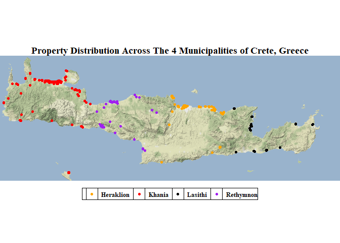

The dataset also had missing values in various variables, both factor and numeric variables. For factor variables, a flag variable was created that took the value 1 where the original variable was NA and 0 otherwise and the NAs in the original variable were replaced with the word “missing”. For numeric variables, flags were created in the same fashion, however, the NAs were replaced with the median of the original variable. Especially for bathrooms, there was only 1 observation with NA for number of bathrooms and an apartment without a bathroom doesn’t make sense. Deep dive into the data suggested that the observation has an apartment that can accommodate 4 people and the average number of bathrooms for apartments with 4 is 1.03, hence imputed this NA with the value 1.

```r
data <- data %>%
  mutate(
    n_beds = ifelse(is.na(n_beds), round(n_accommodates / 2), n_beds), #assume that 1 bed corresponds to about 2 accommodates
    n_bedrooms = ifelse(is.na(n_bedrooms), round(n_accommodates / 2), n_bedrooms),) #assume that bedrooms correlate to around half the number of accommodates
```

The reason for creating the flags is that we believe these were missing at random as we did not find a particular pattern in the missing values. Overall, most of our modified columns were given names in a way so that it would be easier for us to drop the remaining columns. For our dummy variables we used the prefix d_, for numeric n_ etc. Following code snippet shows the columns we focused on.

```r
# Creating the working dataset

# keep columns if contain d_, n_, f_, p_, usd_ and some others
data <- data %>%
  select(matches("^d_.*|^n_.*|^f_.*|^p_.*|^usd_.*"), price, id,room_type,property_type, latitude, longitude)
```

Furthermore, we looked at the distributions of all the variables to see if there was a need to convert to log scale. Only 2 variables had to be converted in log scale; the number of reviews and minimum number of nights, because of these having along right tail. Apart from these variables, others had a near normal distribution. We also checked for the association of all the individual variable with our y-variable (price), where all had either a linear or near-linear relationship with it, hence no higher-order polynomials of the variables were considered. Additionally, we placed a cut off at apartments with a price tag of Euros 300 per night as our small and medium-sized apartments not luxury and are targeted towards the middle and upper-middle class of the economic strata.

Moreover, box plots of property types against price were plotted, conditioned on amenities and municipalities to check for viability of interaction affect on the price. Based on these, we created around 26 interactions between property type and several amenities plus the interaction between property type and their municipalities, to uncover any amenity or municipality specific price effect.

For example, as shown in the figures below, having a first aid kit in the apartment impacts the prices of the apartments significantly. Similarly, availability of dishes and silverware in the apartments some how negatively impact the prices of the apartments. Without dwelling into the reasoning behind such an impact, we let the data speak for itself and included all similar interactions with the property type in our model to capture them. This is also because of our lack of expertise in this business and hence, we relied heavily on data and core statistical methods.

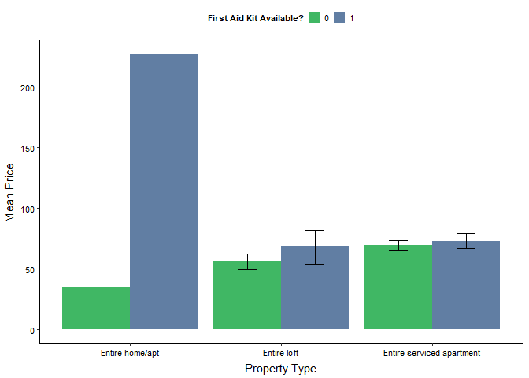

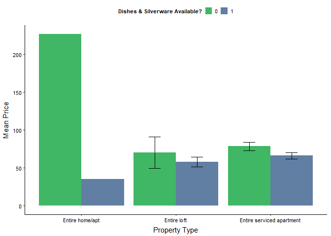

Finally, since the number of observations were extremely small due to specification of our project and the number of available variables were comparatively large, we decided to use the LASSO model as a tool drill down into the variables that LASSO assigned the value of zero to the coefficients. It helped us narrow down the number of predictors to only 54. This was also beneficial because our knowledge of the apartment pricing was limited, and we were not very sure about the relative importance of all the variables.

Out of these 54 predictors, unique variables were identified and then used in the following prediction exercise.

## Prediction

```r
result %>% kbl(caption = "Horse Race of Models - Training data CV RSME", escape = FALSE, digits = 2) %>%
  kable_classic(full_width = F, html_font = "Cambria") %>%
  kable_styling( position = "center")

result_2 %>% kbl(caption = "Horse Race of Models -  Holdout dataset RSME", escape = FALSE, digits = 2) %>%
  kable_classic(full_width = F, html_font = "Cambria") %>%
  kable_styling( position = "center")
```

[output not shown]

### Random Forest

Next, we ran the Random Forest models with 500 trees in each. The first RF model was tuned with random variables option of 6, 8, 10 and minimum node sizes of 5, 10, and 15. This model returned the best tuning parameters of random variables in each tree as 10 and minimum node size of 5. With these parameters, it returned an RMSE of 30.04. On the other hand, the second Random Forest model was run on auto tuning that resulted in an RMSE of 30.26. The auto-tuned RF model chose the same minimum node size of 5, however, it took the number of random variables in each tree at 38. This auto-tuned RF model was fast to run but only because of the small number of observations in the training dataset, however, it may take a lot longer when run on a larger dataset, hence our preference towards tuned RF model, along with the RMSE values.

We further ran diagnostics on the both RF models using Variable Importance (VI) plots, Partial Dependency (PD) plots, and checking subsample performances. For variable importance plots, we grouped together similar variables and re-calculated their importance to gauge the relative importance of these variable groups in predicting the prices. For the purpose of this report, we are showing the diagnostics of the tuned RF model. Amenities stood at the top with a relative importance of around 34% followed by the type of property with 20% relative importance, as shown in the graph below. Based on this, we recommend the management to focus on the types of amenities provided in the apartment towers. The following VI plot shows the top 9 grouped calculated importance of the variables. Unlike in the case study mentioned in the book that conducted similar analysis on London apartments, amenities and property type are most variables in our model. Whereas, in the case study, number of accommodates and room type were the top 2. Number of accommodates in our model stood at the third place, validating the fact that number of accommodates does play a vital role in pricing of the apartments. Apart from that, similar to the case study, locality of the property, reviews, and number of beds are also a part of these top important variables.

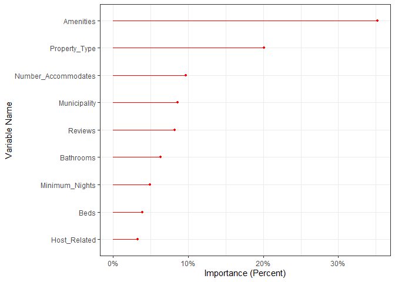

We also looked at the relationship between the predicted prices and number of people a property can accommodate. The relationship seems to be linear, similar to the case study in the book with predicted price being higher for the properties that can accommodate higher number of people.

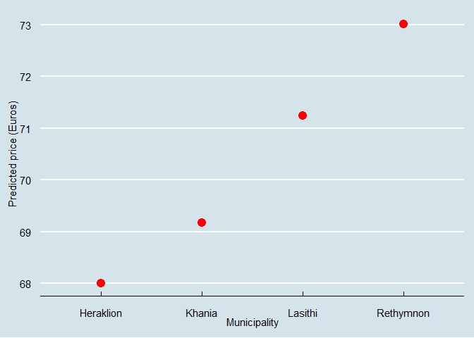

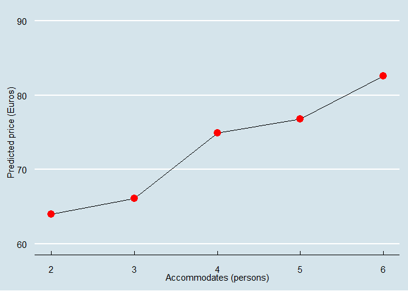

Subsample Analysis

| Var.1 | RMSE | Mean.price | RMSE.price |
| --- | --- | --- | --- |
| Apartment size | NA | NA | NA |
| large apt | 35.56 | 83.52 | 0.43 |
| small apt | 24.03 | 62.39 | 0.39 |
| Beds | NA | NA | NA |
| 2 | 31.43 | 68.31 | 0.46 |
| 3 | 29.61 | 74.48 | 0.40 |
| 4 | 20.03 | 59.12 | 0.34 |
| 5 | 8.80 | 100.00 | 0.09 |
| 6 | 4.51 | 100.00 | 0.05 |
| 8 | 17.07 | 100.00 | 0.17 |
| Municipality | NA | NA | NA |
| Heraklion | 25.26 | 62.61 | 0.40 |
| Khania | 34.56 | 74.49 | 0.46 |
| Lasithi | 29.20 | 80.56 | 0.36 |
| Rethymnon | 28.11 | 80.06 | 0.35 |
| Property Type | NA | NA | NA |
| Entire loft | 25.01 | 58.86 | 0.42 |
| Entire serviced apartment | 31.54 | 76.06 | 0.41 |
| All | 30.69 | 73.60 | 0.42 |

### CART

For the pruned CART model, the cross validated RMSE was 33.6, which was relatively high compared to the CV RMSE of both RF models. Similar to all other models, CART was also run on basic level variables, host related variables, reviews related variables, amenities, and interaction terms that were filtered using the LASSO model. The resulting tree is as follows, having a minimum of observations of 7 and more in the last nodes. CART seemed to have given high importance to number of people a property can accommodate, followed by the log of reviews and number of bathrooms, host acceptance rate, and some amenities.

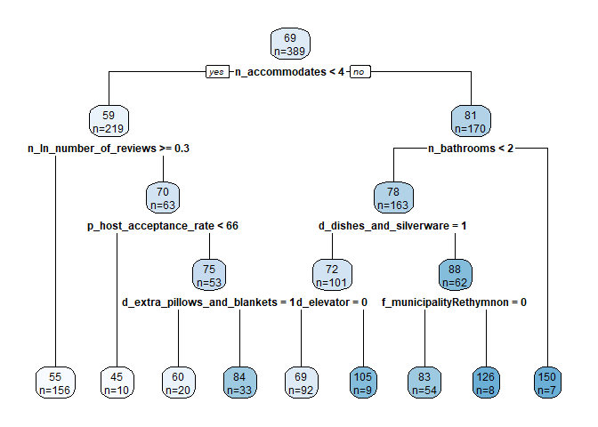

### GBM

The last model we ran was the GBM model. IT was run with an inteaction depth of 5 and the total number of trees run was 250. We set the learning rate at 0.1 and minimum samples at 20. The RMSE for this model was at around 32 Euros, again, more than the two RF models that we had run.

## Conclusion

Based on these model predictions, it is very difficult to drill down into certain predictions. Perhaps it is possible the contradiction between the PD plot results and subsample analysis results could have been because of the very small size of the dataset. If the management is willing to invest in another project where the focus is given on data collection so that the resulting dataset is large enough, the project recommends using the Random Forest model with provided tuning parameters to predict the prices for our apartments in Crete, Greece. Increasing the number of observations may overall increase the predictive power of the models. That said, with the current settings, as mentioned above, the RF tuned model has shown to be more accurate at predicting the prices of 5 and 6 bed properties keeping other things contants, Rethymnon municipality while other things constant, and small apartment sizes while everything else is kept constant.

That said, the following graph plots out the predicted prices versus actual prices on both the training dataset and the holdout dataset based on our best model, tuned RF model. In the plot below, purple points show the predicted vs actual prices for the training dataset and the black squares show the predicted prices vs actual prices in Euros. Looking at the graph, it shows that the prices have been underpredicted overall, again this could be a gift of the very small sample size compared to the number of variables.

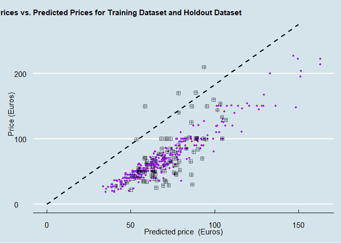

However, if the management is to go ahead with the current predictions based on this small sample size, the project advises to weigh the importance of a simple OLS model as well. A very important idea to keep in mind here is that the OLS model could have been chosen as well, due to its simplicity and the smaller number (13) of predictors in comparison to the size of the dataset. The Random Forest model was chosen here because of the small RMSE in the training dataset. Nevertheless, OLS model’s RMSE was roughly 4 Euros higher than the best RF model and if the management is ready to ignore this marginal amount, we advise to utilize the OLS model for prediction on the live data.